# Линейная алгебра в Julia

Лабораторная работа №4

Дагделен Зейнап Реджеповна

1132236052@rudn.ru

Российский университет дружбы народов

2026-10-22

# Информация

## Докладчик

- Дагделен Зейнап Реджеповна
- студентка НКНбд-01-23
- Российский университет дружбы народов им. П. Лумумбы
- 1132236052@rudn.ru

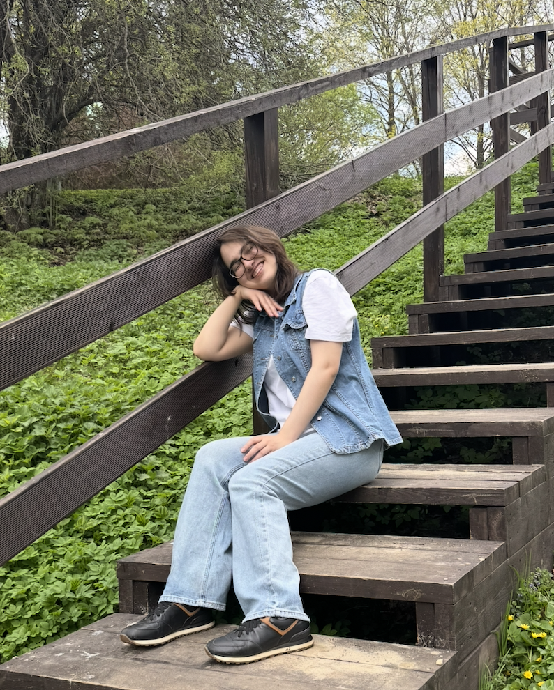

# Введение

## Актуальность

- Линейная алгебра — фундамент машинного обучения, физики, экономики.
- Эффективность матричных вычислений критически важна.
- Язык **Julia** сочетает скорость C и удобство Python.
- Специализированные пакеты позволяют избежать ручной реализации алгоритмов.

## Цели и задачи

- **Цель:** Изучить возможности пакетов Julia для линейной алгебры и оценить эффективность операций.
- **Задачи:**
  - Освоить базовые операции с матрицами и векторами.
  - Изучить факторизации (LU, QR) и спектральное разложение.
  - Провести бенчмаркинг вычислений.
  - Решить прикладные задачи (СЛАУ, модель Леонтьева).

# Теоретическая часть

## Поэлементные операции

- Работают независимо с каждым элементом массива.
- Функции `sum`, `prod`, `mean` в пакете `Statistics`.
- Векторизация операций (`.` — броадкастинг) ускоряет вычисления.
- Позволяет избегать циклов `for`.

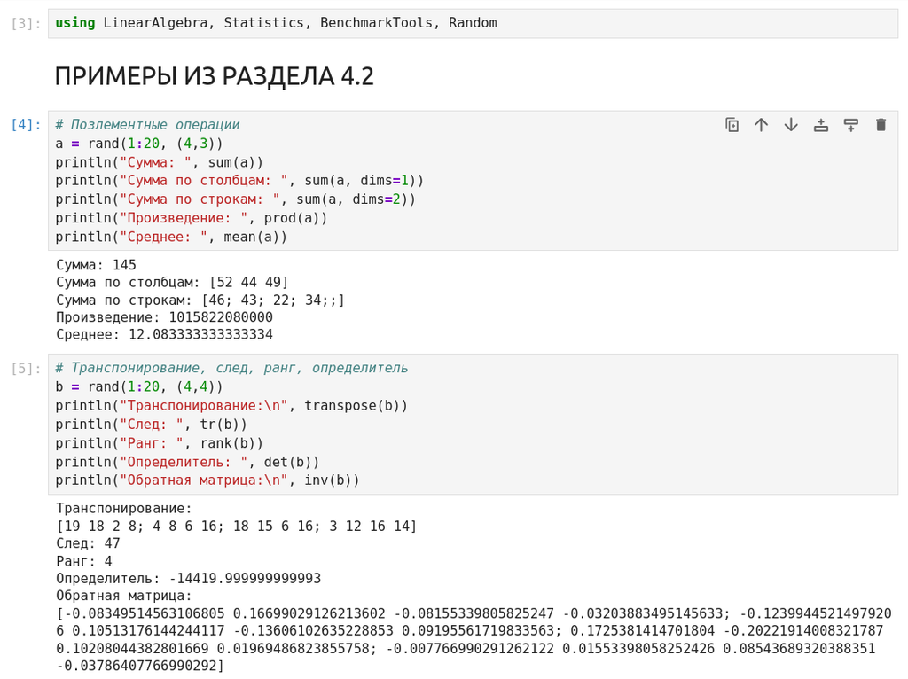

Рисунок 1: Поэлементные операции и операции над матрицами

## Нормы и расстояния

- **Евклидова норма:** $\|\vec{X}\|_2 = \sqrt{\sum x_i^2}$
- **p-норма:** обобщение евклидовой нормы.
- **Расстояние** между векторами: $\|\vec{X} - \vec{Y}\|_2$.
- **Угол** между векторами через скалярное произведение.

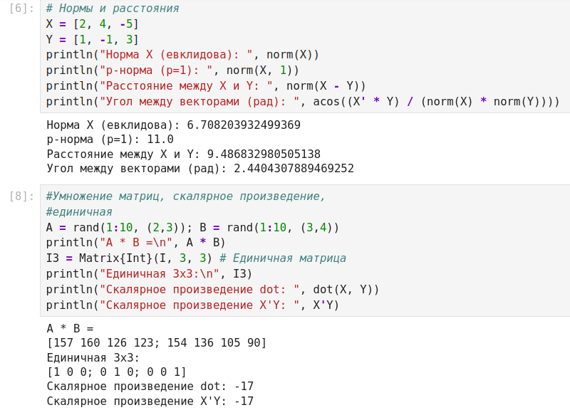

Рисунок 2: Нормы, расстояния и умножение матриц

## Факторизации матриц

- **LU-разложение:** $A = LU$ (нижнетреугольная и верхнетреугольная).
- **QR-разложение:** $A = QR$ (ортогональная и верхнетреугольная).
- Применяются для решения СЛАУ и поиска собственных значений.
- В Julia реализованы в пакете `LinearAlgebra`.

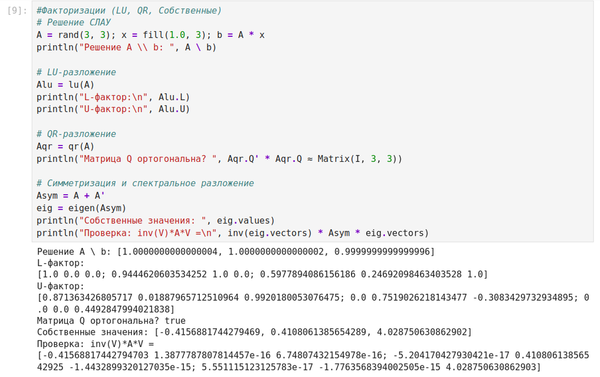

Рисунок 3: Факторизации и спектральное разложение

## Специальные структуры данных

- Julia поддерживает явное указание типа матрицы: `Symmetric`, `Diagonal`, `Tridiagonal`.
- Указание структуры позволяет алгоритмам **игнорировать проверки** и работать быстрее.
- «Зашумленная» матрица теряет свойства симметрии, что резко замедляет вычисления.

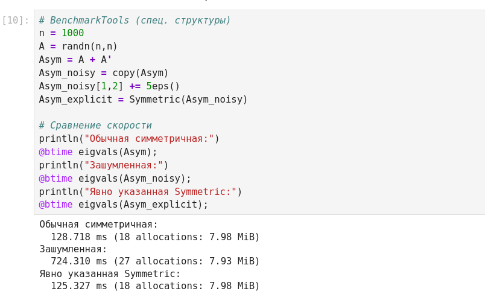

Рисунок 4: Оценка эффективности (BenchmarkTools)

# Прикладные задачи

## СЛАУ и псевдообратная матрица

- Для квадратных систем используется оператор `\`.
- Для переопределенных систем — `pinv` (псевдообратная матрица).
- Проверка совместности через ранги матриц (`rank`).

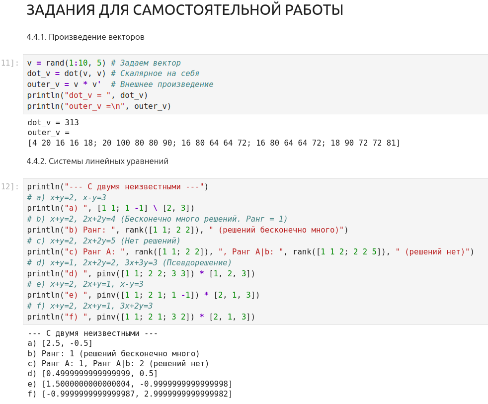

Рисунок 5: Системы линейных уравнений с двумя неизвестными

## Диагонализация и спектр

- `eigen(A)` возвращает собственные значения и векторы.
- Диагональная матрица $\Lambda$ строится через `Diagonal`.
- Спектральное разложение: $A = V \Lambda V^{-1}$.

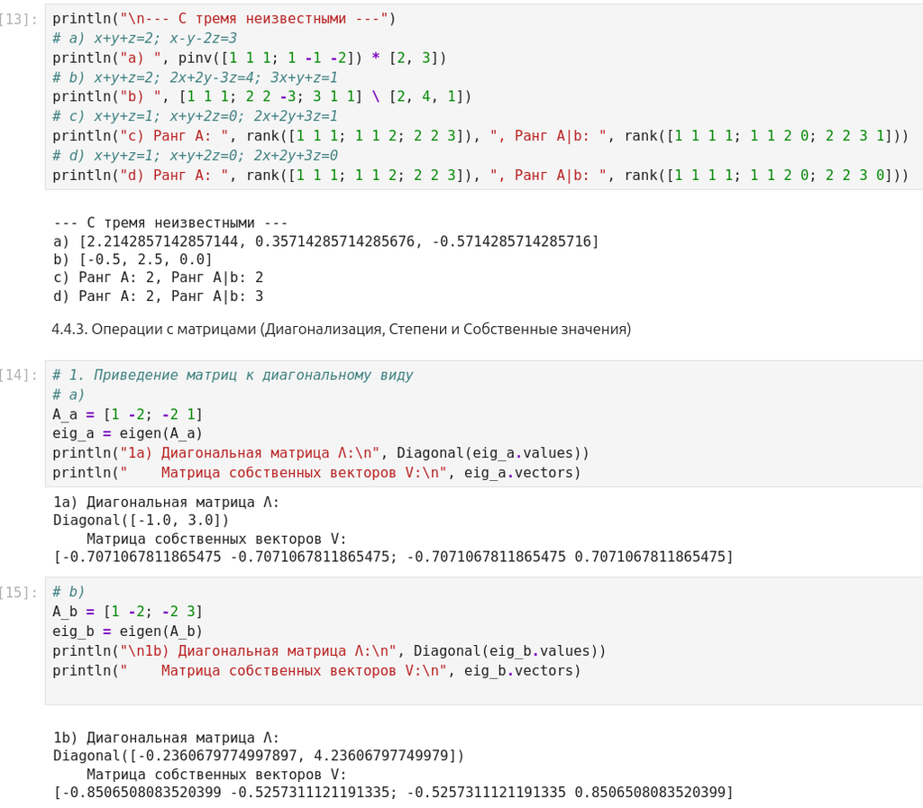

Рисунок 6: Приведение матриц к диагональному виду

## Степени и корни матриц

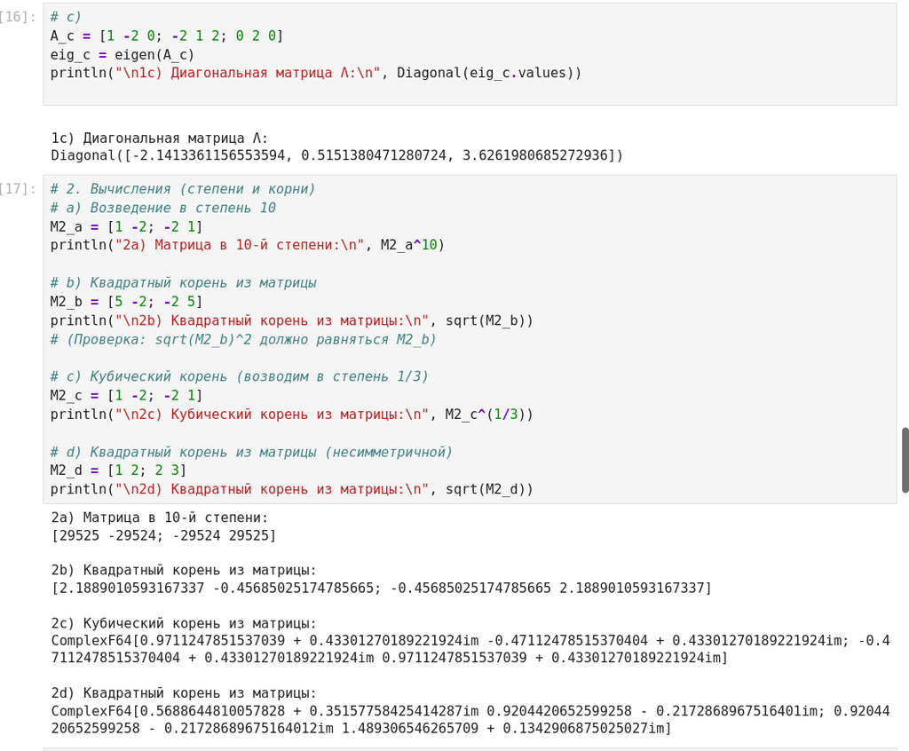

Рисунок 7: Вычисления (степени и корни)

## Модель Леонтьева

- Уравнение: $x - Ax = y$ (межотраслевой баланс).
- Матрица $A$ **продуктивна**, если решение $x \ge 0$ при любом $y \ge 0$.
- **Критерий 2:** все элементы $(E - A)^{-1} \ge 0$.
- **Критерий 3 (спектральный):** $\max|\lambda| < 1$.

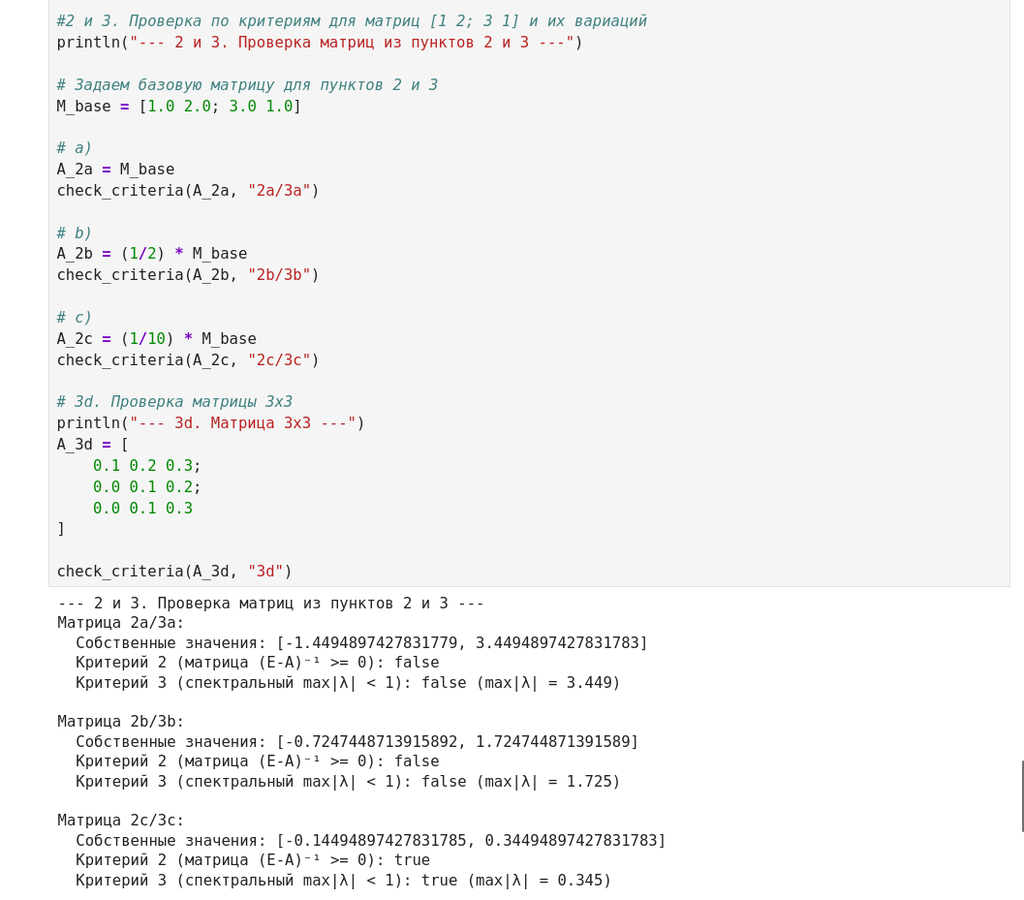

Рисунок 8: Проверка продуктивности матриц по критериям

# Заключение